# Exercise 3 — Point Patterns in Space and Space-Time

BSTA 374 · 25 points · Due Sunday, October 4, 2026, 11:59 pm

Author

Evy Wilkinson · Lehigh University

Published

October 4, 2026

## What this exercise is

The largest lab of the semester. You will decide whether a set of case locations is clustered, at what spatial scale, where the intensity is highest, and whether the clustering is also concentrated in *time* — which is a different claim, and the one that matters for an outbreak.

**Data.** Two files, posted with this exercise. Put them in a `data/` folder beside your `.qmd`.

| File | What it holds |
| --- | --- |
| `dengue_cases_sim.csv` | 500 simulated dengue cases: `case_id`, `onset_date`, `report_date`, `neighborhood`, `age_group`, `lon`, `lat` |
| `study_area.geojson` | the study-area boundary polygon |

These are **simulated** data modeled on a dengue surveillance setting. Nobody’s health information is involved, and the generating process is known — which means your conclusions can be checked.

Each part ends with **starting code**: copy it, fill in the blanks marked `______`, and adapt. It is scaffolding, not a solution.

**ImportantSubmission**

Two things. Submit `LASTNAME_FI_Exercise3.qmd` — the source — to Course Site, with your name in the document header. And publish the rendered HTML to your semester GitHub repository, then paste the live URL into the Course Site submission — Part H is that second step, and it is the one that carries the point.

**Due Sunday, October 4, 2026 at 11:59 pm.** Late work loses 20% per day unless you arrange something with me in advance.

**WarningReproducibility is graded**

Restart R and render from a clean session before submitting. Several parts involve simulation — set a seed at the top and use it, or your numbers will change between the render you checked and the render I grade.

```r
library(sf)
library(dplyr)
library(ggplot2)
library(spatstat)
library(splancs)      # space-time K function
library(plotly)       # space-time cube
set.seed(800137421)      # your student ID works
```

## Part A — From CSV to `ppp` (3 points)

Everything after this part runs on a `ppp` object, so it is worth knowing what one is. `spatstat` does not work with `sf`. A **`ppp`** (“planar point pattern”) holds two things: the coordinates of the events, and a **window** — the region within which they could have been observed. Both are required, because every statistic in this lab is a comparison against what would be expected inside that window: the intensity is $n$ divided by its area, the expected nearest-neighbour distance depends on that intensity, and the edge corrections depend on its shape. Give `spatstat` the wrong window and every number below changes without any warning.

1. Read the case file and the boundary. Report how many cases you have and what one row represents.

There are 500 cases on simulated dengue fever on the file. Each row represents a separate case, with the location, onset and report dates, and age group included for each one.

1. Convert the cases to an `sf` object in **EPSG:4326**, then project both the cases and the boundary to **EPSG:32618** (UTM 18N, metres). One sentence on why the analysis cannot be done in degrees.

   For the graphics in this exercise, the units need to be in meters because they are not spherical like the earth. The locations of the data points could get messed up if they were kept in degrees because measurements would not directly translate to the graphics being made, messing up the clustering. Essentially, meters are units on a flat plane while degrees are units on a spherical plane, for these graphics, we have a flat plane. Latitude and longitude degrees are also not the same distance, further complicating things.
2. Build a `ppp` whose window is the study-area polygon, then print it. Report the number of events and the intensity in cases per km².

   The number of events is 500, meaning there were 500 cases on dengue fever. The intensity in cases per km^2 was 2.63. The window is polygonal.
3. Replace the polygon window with the bounding box of the cases (`Window(pp) <- owin(range(x), range(y))`) and recompute the intensity. Two or three sentences on how much it changed and why the choice of window is a modelling decision rather than a technicality. Then go back to the polygon. The intensity changed from 2.63 for the polygonal boundary to 2.35 for the bounding box. This lowered because the area went up, as bounding boxes are less precise. Polygons offer a more accurate measurement, because they represent the actual area and shape in the real world. A bounding box is much faster because it is simple for the computer to draw, but it is not the real world area or shape. Neither are incorrect, just different choices. When modeling a larger area where precise measurements are not necessary a bounding box could make sense. When modeling a smaller area, or requiring precision, a polygonal shape would be better. The window decision alters the data, and thus the clustering.
4. Map the cases over the boundary.

### Starting code

```r
cases_raw <- read.csv("dengue_cases_sim.csv", stringsAsFactors = FALSE)
area      <- st_read("study_area.geojson", quiet = TRUE) |> st_transform(32618)

cases <- cases_raw |>
  mutate(onset_date  = as.Date(onset_date),
         report_date = as.Date(report_date)) |>
  st_as_sf(coords = c("lon", "lat"), crs = 4326) |>
  st_transform(32618)

win <- as.owin(st_geometry(area))       # the observation window
pp  <- as.ppp(st_geometry(cases))       # coordinates only, with a bounding box
Window(pp) <- win                       # attach the real window

pp                                      # print it: n, window type, extent
```

```
Planar point pattern: 500 points
window: polygonal boundary
enclosing rectangle: [323369.6, 338361.5] x [372065.1, 388098.9] units
```

```r
npoints(pp)
```

```
[1] 500
```

```r
intensity(pp) * 1e6                     # cases per km^2
```

```
[1] 2.626777
```

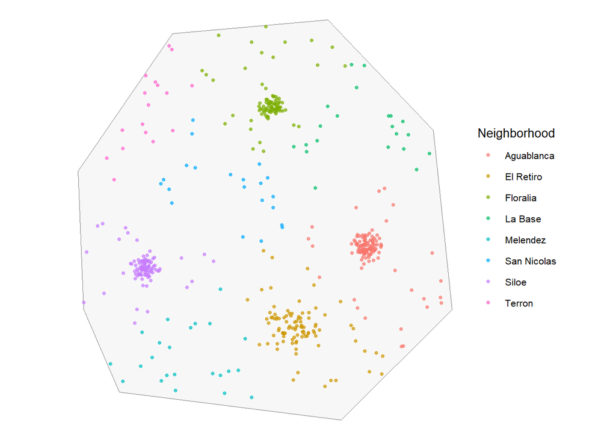

```r
#bounding box window
#pp_box <- pp
#Window(pp_box) <- owin(range(pp$x), range(pp$y))
#pp_box
#intensity(pp_box) * 1e6      # cases per km^2

ggplot() +
  geom_sf(data = area, fill = "gray97",color = "gray50") +
  geom_sf(data = cases, aes(color = neighborhood), size = 1, alpha = 0.7) +
  labs(color = "Neighborhood") + theme_void(base_size = 10)
```

## Part B — Quadrant analysis (3 points)

1. Lay a 6 × 6 grid over the window, map the counts, and compute the mean, variance and **variance-to-mean ratio** from the counts by hand — not from a canned function. Show the arithmetic. Code is under #VMR by hand.
2. State what the VMR is being compared against, and why: under complete spatial randomness the counts are Poisson, and a Poisson distribution has variance equal to its mean. Report where your value sits relative to 1. The Variance to Mean Ratio is compared against 1. This is because the Poisson Regression is used, and in Poisson variance = mean = 1. Under complete spatial randomness the counts are Poisson because in Poisson all points are independent of one another, one event happening does not change the likelihood of another happening. Poisson also assumes that events are happening at a steady average rate. Both the mean and the variance are determined by this rate, lambda, which is why they are equal in Poisson. My value is 41.88, nearly 42 times the Poisson distribution, indicating clustering.
3. Repeat the VMR for at least four grid resolutions and plot VMR against cells per side. Three or four sentences: what does the shape of that curve say about the claim “this pattern is clustered”? The curve peaks at a grid resolution of 6 by 6, and is lowest at a grid resolution of 16 by 16. The more split up the area is with a larger grid resolution, the lower the VMR, as any potential clusters become more and more split up. The shape of the curve shows that grid resolution matters for determining clustering, despite the high VMR, eventually a large enough grid resolution would result in the number becoming 1. In this graph however, the VMR is above 1 in every gird resolution, showing strong evidence that the pattern is clustered.

### Starting code

```r
qc  <- quadratcount(pp, nx = 6, ny = 6)
cnt <- as.vector(qc)

c(k = length(cnt), mean = mean(cnt), var = var(cnt), VMR = var(cnt)/mean(cnt))
```

```
        k      mean       var       VMR
 36.00000  13.88889 581.70159  41.88251
```

```r
#VMR by hand
m <- sum(cnt)/length(cnt)
ss <- sum((cnt - m)^2)
v <- ss/(length(cnt)-1)
VMR <- v/m
VMR
```

```
[1] 41.88251
```

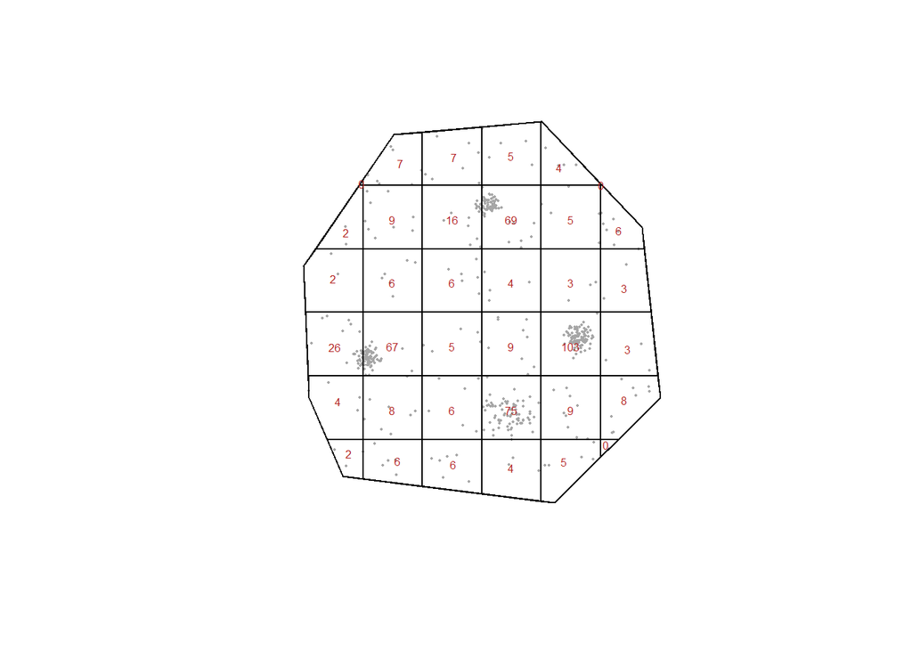

```r
grid_n <- c(3, 4, 6, 8, 12, 14, 16)
vmr <- sapply(grid_n, function(k) {
  v <- as.vector(quadratcount(pp, nx = k, ny = k))
  var(v)/mean(v)
})

plot(pp, pch = 16, cols = "gray65", cex = 0.3, main = "")
plot(qc, add = TRUE, cex = 0.5, col = "firebrick")
```

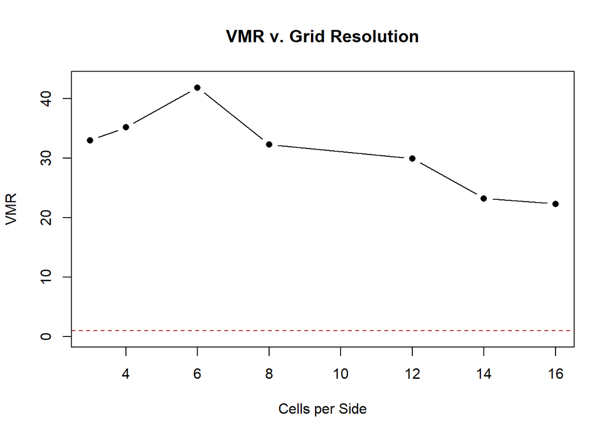

```r
#Graph
plot(grid_n, vmr, type = "b", pch = 16, ylim = c(0, (max(vmr)+1)), xlab = "Cells per Side", ylab = "VMR", main = "VMR v. Grid Resolution")
abline(h =1, lty = 2, col = "firebrick")
```

## Part C — Nearest-neighbour statistics (3 points)

1. Compute `nndist()`, report the observed mean, and compute the CSR expectation $E(d) = 1/(2\sqrt{\lambda})$ **by hand** from your intensity. Report the Clark–Evans ratio $R$ and state the direction of the departure. The Clark–Evans ratio rounds to 0.7. The direction of departure is lower than the null value of 1, meaning that the pattern tends towards clustering. The observed mean is 216 m, and the expected mean is 309 m.
2. Run `clarkevans.test()` with a Monte Carlo null. The window is an irregular polygon, so the Donnelly correction is unavailable — use `correction = "cdf"` with `method = "MonteCarlo"`. One sentence on why an edge correction is needed at all. An edge correction is needed because otherwise points near the edges of the polygon will artificially have less neighbors because their neighbors are cut out from the sample; edge corrections fix this error.
3. Plot the G function with a simulation envelope. Two or three sentences on what G shows that the single ratio $R$ does not. The G function shows the expected values for CSR pattern with the red line (and its gray envelope/confidence interval). The black line represents the actual data in the sample. The black line sharply departs from the red line at first, almost going vertical. This shows that the points in the sample have far more neighbors than those in a CSR would. This differs from the single ratio r by showing at what distance that the sample departs from CSR and when the cluster is the greatest. This graph shows that many points are in small, tight groups, while the rest of the points could be more isolated.

### Starting code

```r
nnd    <- nndist(pp)
lambda <- intensity(pp)
d_exp  <- .5 /sqrt(lambda)

c(observed = mean(nnd), expected = d_exp, R = mean(nnd)/d_exp)
```

```
   observed    expected           R
215.5165165 308.5023198   0.6985896
```

```r
clarkevans.test(pp, correction = "cdf", alternative = "clustered",
                method = "MonteCarlo", nsim = 99)
```

```
    Clark-Evans test
    CDF correction
    Monte Carlo test based on 99 simulations of CSR with fixed n

data:  pp
R = 0.65464, p-value = 0.01
alternative hypothesis: clustered (R < 1)
```

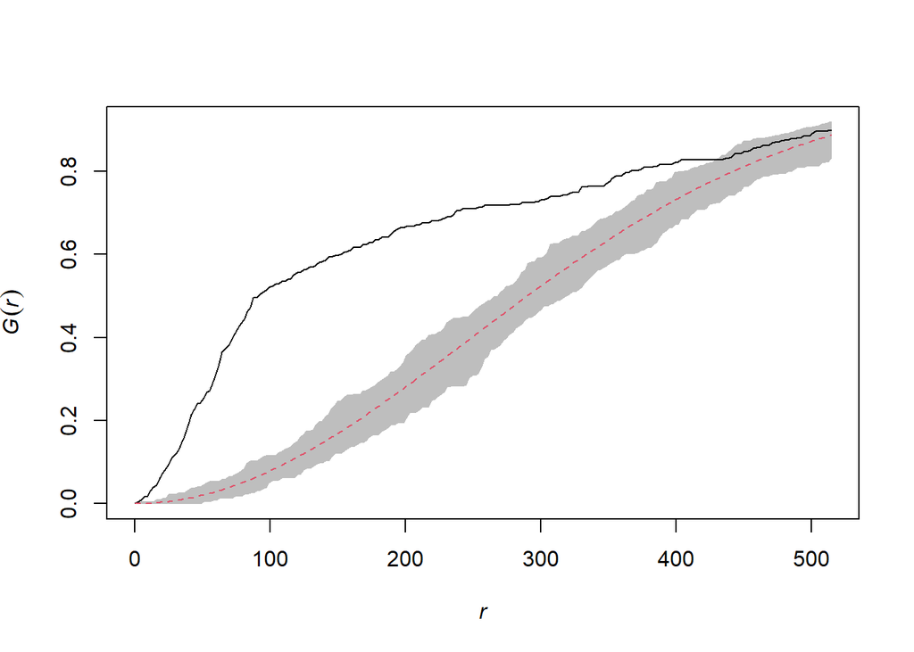

```r
plot(envelope(pp, Gest, nsim = 39, verbose = FALSE), main = "", legend = FALSE)
```

## Part D — Ripley’s K across scales (4 points)

1. Estimate $K(r)$ with an edge correction, then plot the centred L function $\hat{L}(r) - r$ against $r$.
2. Add a **simultaneous** envelope (`global = TRUE`) from at least 99 CSR simulations. State the distances over which the curve leaves the band. The curve leaves the band the entire simulation other then at 0 m, and it gets to less than 250 m at the end. It peaks at about 800 m distance, and then declines from there.
3. Read a **characteristic scale** off the curve — the $r$ at which the departure peaks — and translate it into something a public health officer would recognise: a few city blocks, a neighbourhood, half the city. The curve departs from the band and peaks at 791 meters. This is about a half mile, or a 10 minute walk, and thus represents the size of a neighborhood. This means that this data should be looked at on a neighborhood scale to best see clustering.
4. Three or four sentences: $K$ assumes the intensity is constant across the window. Looking at your map from Part A, is that plausible here? Say what the consequence is for reading the curve — what else, besides interaction between cases, could put it above the envelope. The intensity is not constant across the window because cases are more concentrated in certain areas across the window. This means it is unclear if the curve is caused by the varying intensity or the interaction of the cases. There is no way to seperate the two, so it is something to be aware of. A lot of cases in one area, despite being at different time could create a high spot on this curve, as it does not factor in time.

**Warning**

`global = TRUE` with `nsim = 99` takes a minute or two. Develop with `nsim = 19`, raise it once, and do not re-render in a loop.

### Starting code

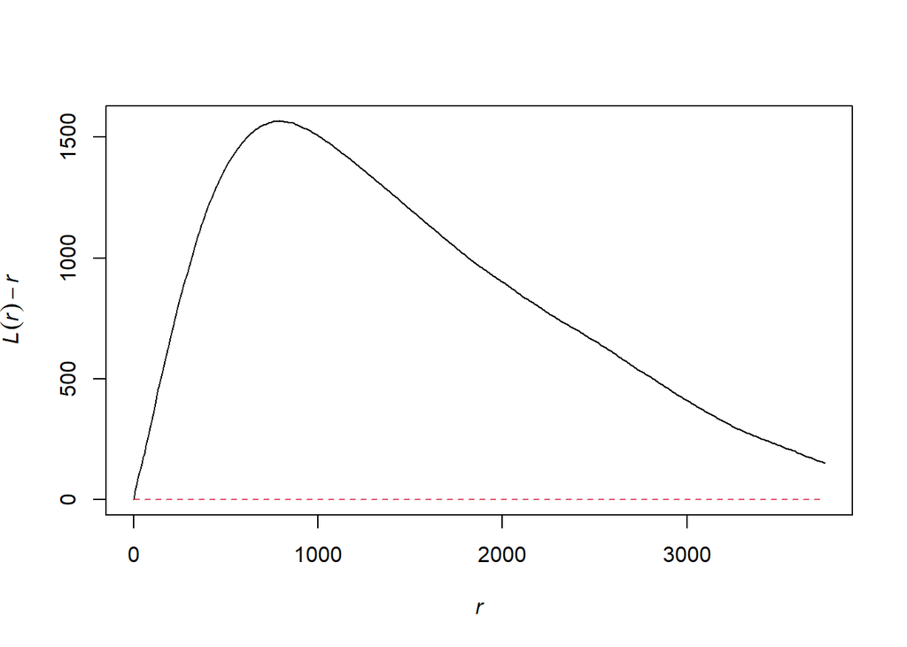

```r
L <- Lest(pp, correction = "isotropic")
plot(L, . - r ~ r, main = "", legend = FALSE)
```

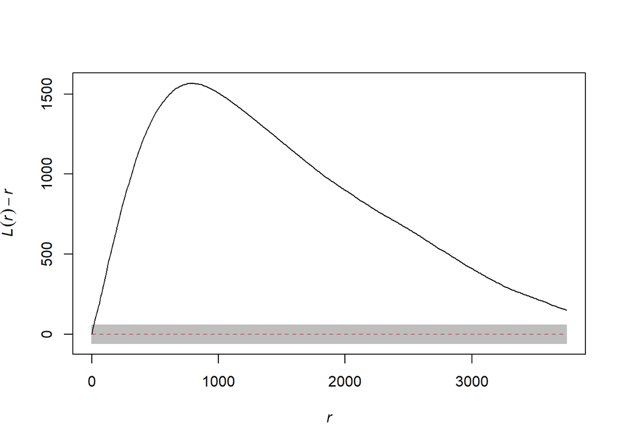

```r
env <- envelope(pp, Lest, nsim = 99, correction = "isotropic",
                global = TRUE, verbose = FALSE)
plot(env, . - r ~ r, main = "", legend = FALSE)
```

```r
dat <- as.data.frame(env)
peak <-dat$r[which.max(dat$obs - dat$r)]
c(peak_r_m = peak, max_excess_m = max(dat$obs - dat$r))
```

```
    peak_r_m max_excess_m
    790.5881    1566.7923
```

## Part E — Kernel density estimation and bandwidth choice (4 points)

K tells you *whether* and *at what distance*; it does not tell you *where*. That is what a kernel intensity surface is for.

1. Estimate the intensity with `density.ppp()` and convert to **cases per km²**. Map it with the cases drawn on top.
2. Produce the same surface at **three bandwidths** — one clearly too small, one clearly too large, and one you would defend — on a **common colour scale** so the panels are comparable. Two or three sentences on what changes and what does not. I chose 400 m as the value I defended because it was close to the bandwidth given by the likelihood-cross validation (bw.ppl). I chose 100 m as the small value because it was well under any of the bandwidths found by the three techniques, and I chose 2000 m because it was well above all of them. At 2000 m, there are no clusters visible at all and the entire background is blue. At 100 m there are bright clusters standing out, whereas in the 400 m there are three clusters clearly visible, but with much smoother edges than the smaller bandwidth. Also, the fourth cluster seen in the 100 m bandwidth has faded at 400 m, but is still visible. The 3 main outbreaks stay visible for two of the graphs, and all graphs represent the same 500 cases.
3. Compare at least two automatic selectors (`bw.diggle()`, `bw.ppl()`, `bw.scott()`). Report the values in metres, say which you adopt and why, and note whether your answer to step 2 would change if you adopted a different one. Diggle’s cross-validated bandwidth (bw.diggle) had a value of 169 m, the likelihood-cross validation (bw.ppl) had a value of 470 m, and Scott’s rule of thumb (bw.scott) had a value of 1251 m. I chose to base my values off of bw.ppl because it works well for finding dense, highly concentrated clusters like the ones visible in earlier maps of the data. When I tried using the value of 1251 m that came from bw.scott, there were not clusters visible at all and the background was one solid color. When I tried using the bw.diggle value of 169 m, it looked similar to the 100 m bandwidth, with clustering visible but very jagged edges, and random points visible as well across the window.
4. Three or four sentences on what this map is and is not. Where is the intensity highest? What would you need in order to turn this surface into a statement about **risk** rather than about counts, and what is the name of the quantity you would compute instead?

This map shows the highest intensity over Aguablanca, with the birghtest and biggest yellow there, which represents the highest concentration of cases. Floralia and Siloe are also bright, with clear clustering. El Retiro shows up in a clump, but the intensity is much less than the other cities. To change this from a count to a map about risks, a relative risk surface could be computed. To do this, numbers about the population at risk would be necessary. This involves mapping both the cases (as we did here) and the population at risk on separate Kernel Density maps and then overlaying them, with cases over controls (population at risk).

**TipWhat earns full marks here**

Step 4, and the common colour scale in step 2. Two surfaces at different bandwidths with independently stretched legends look like different data; a reader cannot compare them, and neither can you.

### Starting code

```r
sig <- bw.diggle(pp)
c(diggle = bw.diggle(pp), ppl = bw.ppl(pp), scott = mean(bw.scott(pp)))
```

```
   diggle       ppl     scott
 168.6955  469.9289 1250.5481
```

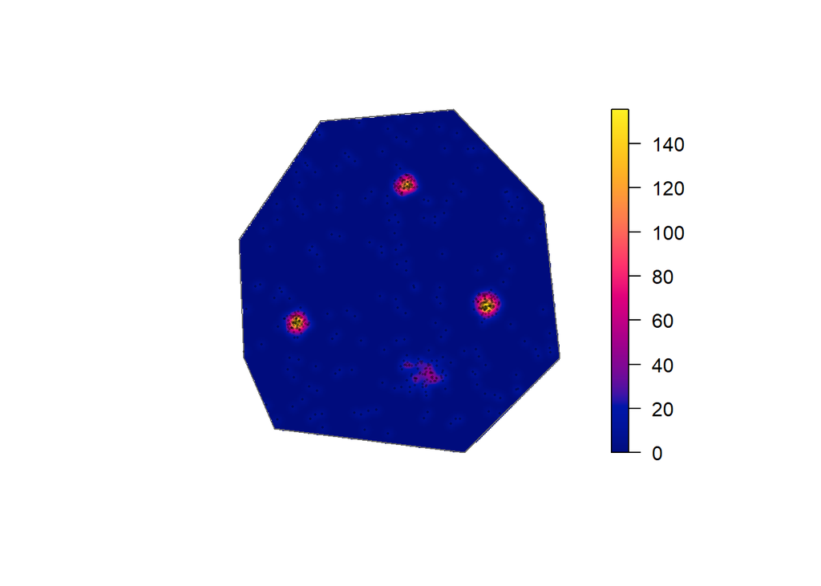

```r
kde <- density(pp, sigma = sig, eps = 50) * 1e6       # cases per km^2
plot(kde, main = "", ribargs = list(las = 1))
plot(Window(pp), add = TRUE, border = "grey40")
points(pp, pch = 16, cex = 0.25, col = rgb(0, 0, 0, 0.35))
```

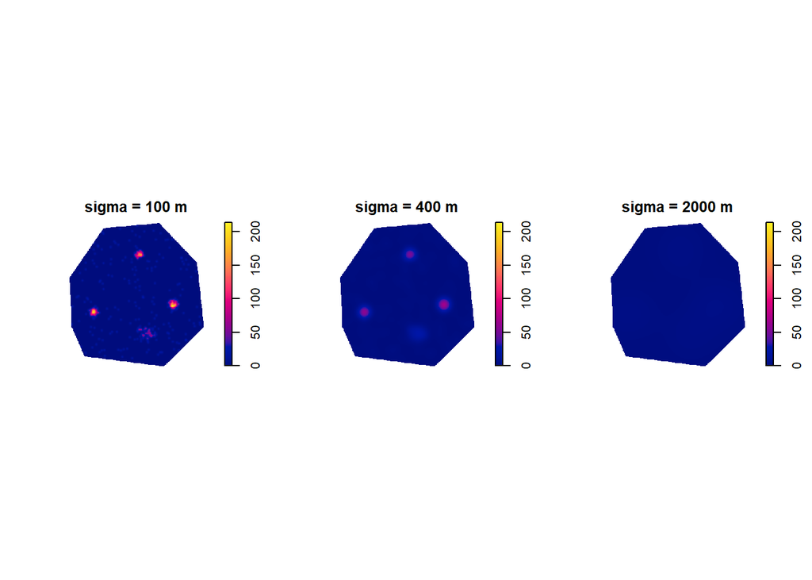

```r
sigmas <- c(100, 400, 2000)                   # too small, defensible, too large
surf   <- lapply(sigmas, function(s) density(pp, sigma = s, eps = 50) * 1e6)
zmax   <- max(sapply(surf, max))                      # one scale for all panels

par(mfrow = c(1, 3))
for (i in seq_along(surf))
  plot(surf[[i]], main = paste0("sigma = ", sigmas[i], " m"), zlim = c(0, zmax))
```

## Part F — Space-time kernel density (3 points)

A single intensity surface pools six months. An outbreak is a hotspot that exists in some weeks and not others, and pooling hides exactly that.

1. Split the cases into **monthly** patterns and estimate a kernel surface for each, using **one bandwidth for all months** and **one colour scale for all months**. Display them as small multiples.
2. Two or three sentences on why both of those constraints are necessary, and what a reader would wrongly conclude if each panel were scaled to its own maximum. It is necessary to keep all of the graphs at the same color scale and bandwidth because otherwise you lose the ability to compare the graphs properly. If they are using different bandwidth, they are incomparable because they are looking at a different “zoom” (neighborhood versus state for example). If they are on different color scales than hotspots, or how strong the outbreak is, could be confused. A reader could wrongly conclude if each panel was scaled to its maximum that the outbreak never ended, or was bigger than it actually was.
3. Name the months and locations where the intensity is high, and say which hotspots persist across months and which appear and disappear. In February Floralia has a high intensity. In March Aguablanca had a high intensity. In May Siloe had a high intensity. At the bandwidth I chose none of the hotspots persisted with a high intensity for more than a month. El Retiro was present at a low intensity but still visible January to June.
4. Build a **space-time cube**: an interactive 3D scatter with easting, northing and day-of-study on the three axes, coloured by neighbourhood. Rotate it until the structure is visible, then set a viewing angle that makes your point and keep it. One or two sentences on what the cube shows that the small multiples do not, and vice versa — look in particular for the difference between a compact blob and a vertical column.

The cube shows the outbreaks over time. On the small multiples, outbreaks that came and went were easy to see, but ones that were slowly ongoing were not. This cube shows that. The column of points in red shows the ongoing chronic hotspot in El Ritero that other visuals were unable to show. This is because it factors in time on a scale.

**Warningplotly renders in HTML only**

The cube is an HTML widget: it appears in an HTML render and is silently dropped from a PDF one. The two chunks below are gated on `knitr::is_html_output()`, so whichever format you render gets a working figure. If you publish the HTML, keep `embed-resources: true` — otherwise the widget lives in a `_files/` folder that has to travel with the page.

**NoteIf you want the proper estimator**

Steps 1–3 are a discretised space-time KDE: one spatial bandwidth, and a temporal “bandwidth” equal to one month, applied as a hard cut. The continuous version smooths in time as well, with a separate temporal bandwidth, and lives in the `sparr` package — `spattemp.density()` with `h` and `lambda`, then `spattemp.slice()` to pull out time slices. Using it is worth up to **2 bonus points** if the monthly version is already complete and correct. Do not start here.

### Starting code

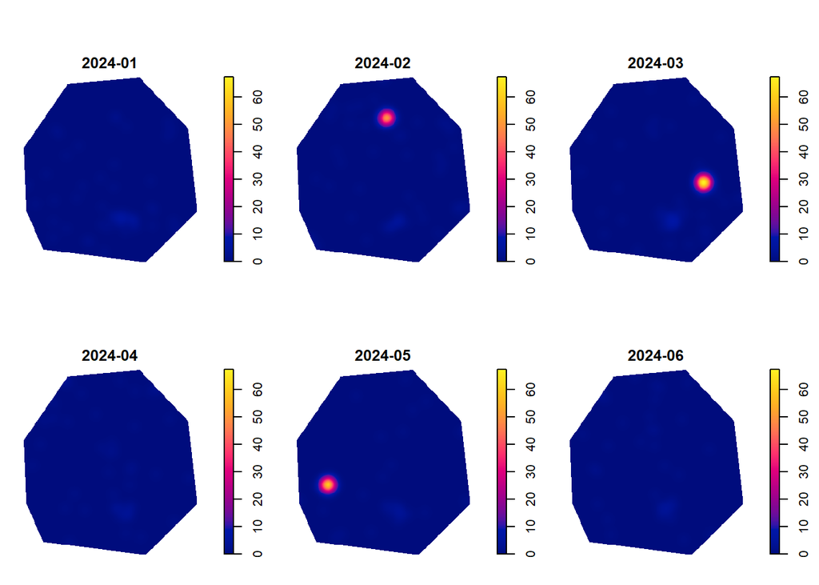

```r
cases$month <- format(cases$onset_date, "%Y-%m")
h <- 400                                  # one bandwidth, chosen in Part E

by_month <- lapply(sort(unique(cases$month)), function(m) {
  sub <- cases[cases$month == m, ]
  p   <- ppp(st_coordinates(sub)[, 1], st_coordinates(sub)[, 2], window = Window(pp))
  density(p, sigma = h, eps = 50) * 1e6
})

zmax <- max(sapply(by_month, max))        # common scale across months

par(mfrow = c(2, 3), mar = c(1, 1, 2, 2))
for (i in seq_along(by_month))
  plot(by_month[[i]], main = sort(unique(cases$month))[i], zlim = c(0, zmax))
```

```r
xy  <- st_coordinates(cases)
cube <- data.frame(E = xy[, 1], N = xy[, 2],
                   day = as.numeric(cases$onset_date - min(cases$onset_date)),
                   hood = cases$neighborhood)
```

```r
plot_ly(cube, x = ~E, y = ~N, z = ~day, color = ~hood,
        type = "scatter3d", mode = "markers",
        marker = list(size = 3, opacity = 0.75)) |>
  layout(scene = list(xaxis = list(title = "easting (m)"),
                      yaxis = list(title = "northing (m)"),
                      zaxis = list(title = "day of study"),
                      camera = list(eye = list(x = -1.6, y = 1.5, z = 0.3))
                      ))
```

[interactive chart not shown]

```r
scatterplot3d::scatterplot3d(cube$E, cube$N, cube$day, pch = 16, cex.symbols = 0.4,
                             color = as.integer(factor(cube$hood)),
                             xlab = "easting (m)", ylab = "northing (m)", zlab = "day")
```

## Part G — The space-time K function (4 points)

Spatial clustering and space-time clustering are different claims. A neighbourhood with chronically high incidence is clustered in space in every month; an outbreak is clustered in space *and* time together. Diggle’s space-time K function separates them by comparing the joint function with the product of the two marginals:

$$D(s, t) = K_{st}(s, t) - K_s(s)\,K_t(t)$$

$D = 0$ means space and time are independent — cases may cluster spatially, temporally, or both, but not *jointly*. $D > 0$ is space-time interaction.

1. Build the inputs `splancs` expects: a two-column matrix of projected coordinates, a numeric time vector (days since the first onset), and the boundary as a matrix of vertices.
2. Compute $K_s$, $K_t$ and $K_{st}$ with `stkhat()`. Justify your choice of spatial distances `s` and time lags `tm` in one sentence each — what scales are plausible for a mosquito-borne disease? I based the distances I chose off of how far mosquitoes tend to fly, because this is a limiting factor. The mosquito that spreads dengue fever has a flight range of only 100-200 meters over its lifetime, so I lowered the finer scale distance but kept a higher max to account for human movement as well. I chose the time to account for the incubation period of dengue fever in both mosquitoes and humans.
3. Plot **both** $D(s,t)$ and the standardised version $D_0(s,t) = K_{st}/(K_s K_t) - 1$. One or two sentences on why the two surfaces have different shapes: $K$ functions are cumulative, so $D$ accumulates and then flattens, while $D_0$ measures the *proportional* excess and falls away once you leave the scale of the clustering. This is the same move as plotting $\hat{L}(r) - r$ instead of $\hat{K}(r)$ in Part D. For D, it begins with a small amount of cases at a short distance, the larger the radius, the more cases included and so the graph stretches up. At some point, all of the cases in the cluster are within the circle, so increasing the circle changes nothing, causing the top of the graph to flatten out. DO is different because is shows the percentage of extra cases, which because there is a cluster, is very large at shorter distances and gets lower the larger the difference, hence the graph’s shape.
4. A surface is hard to read against nothing. Build a **permutation envelope**: shuffle the onset dates across the fixed locations, recompute $D_0$, repeat 99 times, and take the upper 97.5% quantile at each $(s, t)$. Then plot $D_0$ against $s$ as a curve per time lag, with its envelope — the space-time analogue of the envelope you used for $L$. Shuffling the dates destroys any space-time interaction while leaving both marginal patterns exactly as observed, which is the correct null here.
5. Read the peak off those curves — a distance and a lag — and say what the pair means for this disease. The lag tells about how close the cases of dengue fever were in time to eachother. The graphs shows that for a lag of 3, it had up to 6 times as many close pairs as expected (compared to the envelope not seen below the graph). The lag 3 peaked at about 50-500 meters, indicating that cases are strongly clustered. The distance slides downward over the course of the graph, peaking at the beginning for all lags.This indicates clustering because there are much more close pairs than expected at short distance.
6. Run `stmctest()` for a single global p-value. It sums the residuals $\hat{D}(s,t)$ over the whole grid into one statistic $U$, recomputes it under permuted dates, and returns the observed value as `$t0` and the permuted ones as `$t`. Report the p-value as $(1 + \#\{t \geq t_0\}) / (1 + B)$ and plot the null distribution with the observed value marked. One sentence on what this test adds to the curves in step 4, and what it cannot tell you. p is less than or equal to 0.001 This test gets rid of the issue of some of the graphs looking like there is clustering just because of luck by testing a lot of them. It cannot tell us where or how strong the clustering is.
7. Five or six sentences. Tabulate cases by neighbourhood and month. At least one neighbourhood contributes to the spatial clustering of Part D without contributing to the space-time interaction here. Identify it, explain what distinguishes it from the others, and say what each of the two patterns would mean for someone deciding where to send a vector-control team this week. The neighborhood is El Retiro. During outbreaks, other cities have numbers in the 70-105 range,with a normal range of 1-7 cases per month. El Retiro has cases between 13-24 constantly. The other neighborhoods have outbreaks where cases rise in a short period of time and then lower significantly. El Retiro has a raised level of cases at all times, with no flare ups. This means that it shows up in graphics as clustering often, but is not the same as the other cities. For El Retiro, a vector-control team would hav eot try to identify and lower a chronic problem, and would need a sustained vactor control team. The other cities only need a vector control team when they are beginning or mid outbreak.

**WarningNever report $p = 0$**

`mean(mc$t >= mc$t0)` returns 0 when no permutation beats the observed value, and 0 is not a p-value — with $B$ permutations you cannot resolve anything below $1/(B+1)$. Always add the observed value to both counts, as above. With 999 permutations the smallest reportable value is 0.001, and the honest phrasing is “$p \leq 0.001$”, not “$p < 0.0001$”.

**Note**

`splancs` is old and its arguments are terse: `stkhat(pts, times, poly, tlimits, s, tm)`, where `tlimits` is the time range, `s` the spatial distances and `tm` the time lags. `?stkhat` and `?stmctest` are short. A **Knox test** on a distance and time threshold of your choosing is an acceptable substitute if you defend both thresholds — say explicitly if you go that route.

### Starting code

##count by putting cylinders or spheres around points and making tehm bigger (instead of circles) (Space tiem continum)

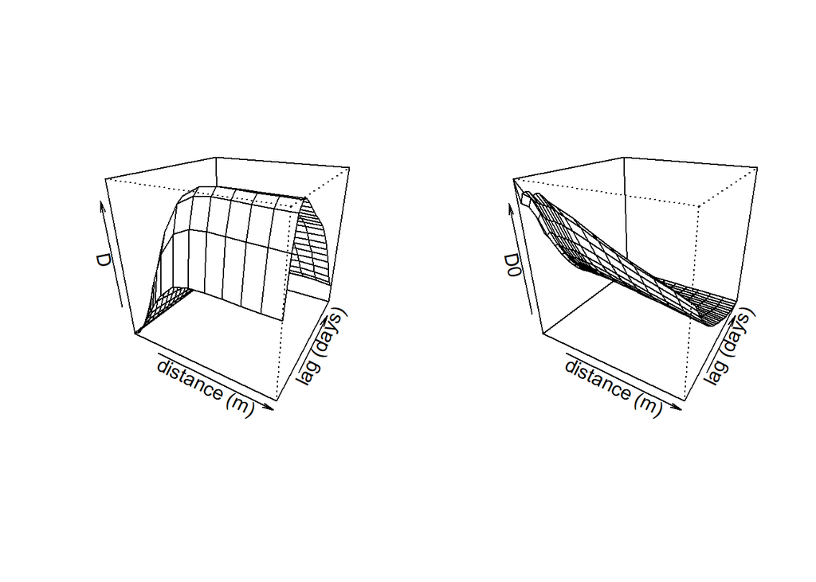

```r
xy    <- st_coordinates(cases)
pts   <- as.points(xy[, 1], xy[, 2])  #gives two column matrix
times <- as.numeric(cases$onset_date - min(cases$onset_date))   #gives numeric time vector
bdry  <- st_coordinates(area)[, 1:2]         # drop the closing vertex if duplicated    #gives boundary

s  <- c(seq(50, 500, by = 50), seq(600, 2000, by = 200))   # finer near the origin
tm <- seq(3, 70, by = 3)                     # days

stk <- stkhat(pts, times, bdry, c(0, max(times)), s, tm)   #computes Ks, Kt, and Kst

D  <- stk$kst - outer(stk$ks, stk$kt)                  # raw excess
D0 <- stk$kst / outer(stk$ks, stk$kt) - 1              # standardised excess

par(mfrow = c(1, 2))
persp(s, tm, D,  theta = 30, phi = 25,
      xlab = "distance (m)", ylab = "lag (days)", zlab = "D")
persp(s, tm, D0, theta = 30, phi = 25,
      xlab = "distance (m)", ylab = "lag (days)", zlab = "D0")
```

```r
# permutation envelope: shuffle the dates, keep the locations
B <- 99
perm <- replicate(B, {
  st <- stkhat(pts, sample(times), bdry, c(0, max(times)), s, tm)
  st$kst / outer(st$ks, st$kt) - 1
})
hi <- apply(perm, c(1, 2), quantile, 0.975)

k <- c(1, 3, 7, 14)                          # lags to show
matplot(s, D0[, k], type = "l", lty = 1, lwd = 2, xlab = "distance s (m)",
        ylab = expression(D[0](s, t)))
matlines(s, hi[, k], lty = 3, lwd = 1)
abline(h = 0, col = "grey")
legend("topright", legend = paste("lag <=", tm[k], "d"), lty = 1, lwd = 2,
       col = 1:4, bty = "n")

mc <- stmctest(pts, times, bdry, c(0, max(times)), s, tm, nsim = 999, quiet = TRUE)

(1 + sum(mc$t >= mc$t0)) / (1 + length(mc$t))   # global Monte Carlo p-value
```

```
[1] 0.001
```

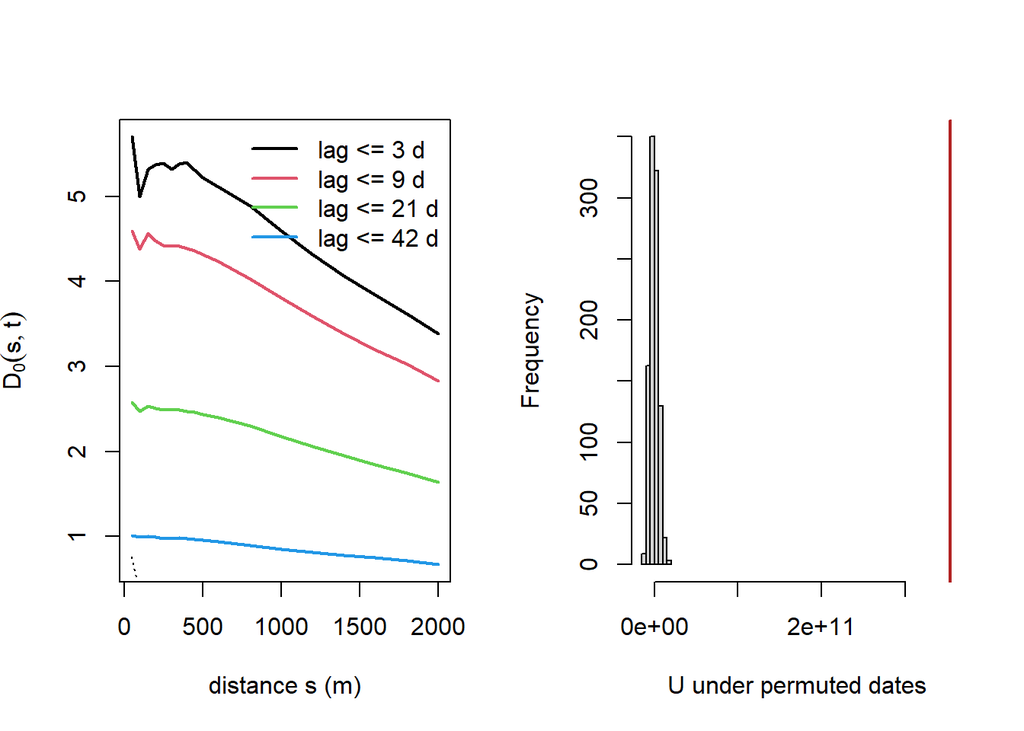

```r
hist(mc$t, xlim = range(c(mc$t, mc$t0)), xlab = "U under permuted dates", main = "")
abline(v = mc$t0, col = "firebrick", lwd = 2)
```

```r
table(cases$neighborhood, cases$month)
```

```
              2024-01 2024-02 2024-03 2024-04 2024-05 2024-06
  Aguablanca        5       7     105       5       1       2
  El Retiro        20      13      24      14      13      13
  Floralia          3      72       6       4       2       8
  La Base           3       8       1       4       4       1
  Melendez          7       4       3       3       4       2
  San Nicolas       4       4       1       5       2       5
  Siloe             6       3       3       2      84       3
  Terron            2       3       2       7       0       3
```

## Part H — Rendering and publication (1 point)

The `.qmd` is the submission, but the rendered page is what anyone else can actually read — and by the end of the semester this repository is your portfolio.

1. Render to **HTML** from a clean session, with the seed set and every package loaded explicitly, then commit both the `.qmd` and the rendered output to your semester repository, in the folder your site is built from.
2. Push, wait for GitHub Pages to rebuild, and **open the published URL yourself** to check it. A page that renders locally and 404s online is not submitted.
3. Put the URL of the published page in your document header and in your Course Site submission.

The point is for a page that works: rendered, pushed, and reachable at the URL you supply.

**WarningTwo things that break the published page**

`embed-resources: true` is already set in the header — keep it. Without it the `plotly` cube in Part F lives in a `_files/` folder that must be committed alongside the HTML, and forgetting it gives a page with a blank space where the cube should be.

Relative paths to `data/` work locally because your working directory is the `.qmd`’s folder. They will also work on the site *as long as you commit the data files*. Check the live page, not the local preview.

## AI use

End your document with a short **AI use note**: which tools, what for, at which stage. Two or three sentences.

AI use is unrestricted in this course and costs you nothing, but you must be able to explain every line you hand in. The note carries no points — it is simply expected, the way a methods section is.

AI use: I used Claude to help explain questions I did not understand and make sense of the large amount of information. I used it for code suggestions and explanations.

## Rubric

| Part | What is assessed | Points |
| --- | --- | --- |
| **A** | Correct import, CRS and window; `ppp` built and explained; effect of the window argued | 3 |
| **B** | VMR computed from counts; benchmark of 1 explained; resolution sweep interpreted | 3 |
| **C** | $E(d)$ derived and $R$ interpreted; Monte Carlo test correct; G compared with $R$ | 3 |
| **D** | Centred L with a simultaneous envelope; characteristic scale read and translated; stationarity assumption discussed | 4 |
| **E** | Surface in interpretable units; three bandwidths on a common scale; selectors compared; density-is-not-risk argument | 4 |
| **F** | Monthly surfaces with common bandwidth and scale; persistent vs transient hotspots named; space-time cube | 3 |
| **G** | Space-time K computed; $D_0$ with a permutation envelope; peak distance and lag read off; the spatial-only neighbourhood identified and the operational difference explained | 4 |
| **H** | Clean render to HTML, published to GitHub Pages; working URL supplied | 1 |
|  | **Total** | **25** |

Writing counts for roughly 15% within each part — more than in Exercise 1, because more of this lab is interpretation. A submission that is all code and no sentences cannot score above about 50%.

## Getting help

- Office hours, or email with the code and the exact error message.
- `splancs` in Part G is the one place where the documentation is thin. Start early enough that you can ask.
- Stuck for more than thirty minutes on something mechanical: ask rather than persevere.